# Preprocessing & Text Mining

2024-01-17

Following the pre-processing and Text Mining techniques have been used draw insight from text provided and produce informative visualization.

#### Load Libraries

```r
libraries <- c("tm", "tidytext", "ggplot2", "wordcloud", "syuzhet", "dplyr", "tibble", "textstem", "textdata", "tidyr")

#install.packages(libraries) # Comment out after first execution

for (lib in libraries) {
  library(lib, character.only=TRUE) #Library takes function names without quotes, character only must be used in a loop of this kind.
}
```

#### Load Dataset

```r
# Define file path
filepath <- 'D:\\1_Dilshan\\7_USW_MSc in Data Science\\4_Data Mining & Statistical Modeling\\Assignment 1\\MS4S09_CW_Book_Reviews.csv'

# convert the dataframe into tibble
book_data <- as_tibble(read.csv(filepath, stringsAsFactors = FALSE))

# Inspect summary and first few rows of data
print(summary(book_data))
```

```
##     Title             Book_Price     Reviewer_id            Rating
##  Length:59296       Min.   :  1.00   Length:59296       Min.   :1.000
##  Class :character   1st Qu.: 10.36   Class :character   1st Qu.:4.000
##  Mode  :character   Median : 14.15   Mode  :character   Median :5.000
##                     Mean   : 20.81                      Mean   :4.231
##                     3rd Qu.: 22.99                      3rd Qu.:5.000
##                     Max.   :995.00                      Max.   :5.000
##       Time           Review_title       Review_text        Found_helpful_ratio
##  Min.   :8.688e+08   Length:59296       Length:59296       Min.   :0.0000
##  1st Qu.:1.087e+09   Class :character   Class :character   1st Qu.:0.0000
##  Median :1.169e+09   Mode  :character   Mode  :character   Median :0.6667
##  Mean   :1.173e+09                                         Mean   :0.5491
##  3rd Qu.:1.279e+09                                         3rd Qu.:1.0000
##  Max.   :1.362e+09                                         Max.   :1.0000
##   Publisher         First_author          Genre
##  Length:59296       Length:59296       Length:59296
##  Class :character   Class :character   Class :character
##  Mode  :character   Mode  :character   Mode  :character
##
##
##
```

```r
print(head(book_data))
```

```
## # A tibble: 6 × 11
##   Title            Book_Price Reviewer_id Rating   Time Review_title Review_text
##   <chr>                 <dbl> <chr>        <int>  <int> <chr>        <chr>
## 1 In Six Days: Wh…      10.2  APD7XINUVG…      4 9.99e8 Solid testi… "Working f…
## 2 Lord Jim              15.6  AITANZIKX8…      5 9.16e8 &quot;You d… "A terrifi…
## 3 White Socks Only       5.16 AYB19RB36G…      4 1.34e9 White Socks… "As I open…
## 4 The Secret of t…      15.0  A1BOLCK0Q5…      5 1.28e9 great!       "Excellent…
## 5 Left to Tell: D…      17.5  A3WKJ88K78…      5 1.36e9 Great Book   "This book…
## 6 Don't Make Me T…      20.9  A1E6I4IPWW…      5 1.20e9 Don't think… "Excellent…
## # ℹ 4 more variables: Found_helpful_ratio <dbl>, Publisher <chr>,
## #   First_author <chr>, Genre <chr>
```

The given data set consists of 11 columns and 59,296 rows

#### Data Selection and clening

```r
# Select Columns
book_data_1 <- book_data %>%
  select(c("Title","Rating", "Review_title", "Review_text", "Publisher", "First_author", "Genre"))

book_data_1 <- na.omit(book_data_1) # Removes all rows containing null values

book_data_1$Review_no <- 1:nrow(book_data_1)
```

In column selection the “Reviewer_id” is not taken where it is not a unique id so created a column of “Review_no” as a unique number

#### count and filter

```r
# count number of reviews by Title
book_data_counts <- count(book_data_1,Title , sort=TRUE)
book_data_counts <- book_data_counts[book_data_counts$n > 100, ]# Filter book titles with more than 100 reviews

summary(book_data_counts) # Print summary statistics to see min. max. and average no. of reviews
```

```
##     Title                 n
##  Length:20          Min.   :105.0
##  Class :character   1st Qu.:119.0
##  Mode  :character   Median :135.5
##                     Mean   :154.8
##                     3rd Qu.:158.2
##                     Max.   :276.0
```

The selected book titles have minimum of 105 number of reviews and maximum of 276 number of reviews. Number of reviews each books are not equal.

#### Data Sampling

```r
# Randomly select 5 book titles
set.seed(1) # Set random seed for repeatability

# Take sample of 5 book titles
sample_index<- sample(length(unique(book_data_counts$Title)), 5) #returns index for sample
sampled_book_title <- unique(book_data_counts$Title)[sample_index] # Take book titles at index defined previously

book_data_1 <- book_data_1 %>%
  filter(Title %in% sampled_book_title) # Filter only the above sampled 5 book titles

# Initialize an empty dataframe to store sampled reviews
sampled_reviews <- data.frame()

# Loop through each selected titles and sample 100 reviews
for (book in sampled_book_title) {
  reviews <- book_data_1 %>%
    filter(Title == book) %>%
    sample_n(size = 100, replace = TRUE)
  sampled_reviews <- bind_rows(sampled_reviews, reviews)
}
book_data_1 <- sampled_reviews
# Display the sampled reviews
head(book_data_1)
```

```
##           Title Rating                           Review_title
## 1 Good to Great      5                            Great Book!
## 2 Good to Great      5                The Power of a Hedgehog
## 3 Good to Great      3          OK material, grating delivery
## 4 Good to Great      5           Best book in the business...
## 5 Good to Great      5 Before you buy this book, know thyself
## 6 Good to Great      5                             Good Book.
##                                                                                                                                                                                                                                                                                                          …
## 1                                                                                                                                                                                                                                                                                                        …
## 2                                                                                                                                                                                                                                                                                                        …
## 3                                                                                                                                                                                                                                                                                                        …
## 4                                                                                                                                                                                                                                                                                                        …
## 5 I believe this book is brilliant (how often does one get a business book based on a broad set of DATA, and not assertions or a few case studies?) but it is not meant to be everything to everyone.It will not help a struggling company out of the dark ages. If you're looking for help with cash flo…
## 6                                                                                                                                                                                                                                                                                                        …
##        Publisher First_author                Genre Review_no
## 1 HarperBusiness  Jim Collins Business & Economics     14293
## 2 HarperBusiness  Jim Collins Business & Economics      3257
## 3 HarperBusiness  Jim Collins Business & Economics     53577
## 4 HarperBusiness  Jim Collins Business & Economics     17087
## 5 HarperBusiness  Jim Collins Business & Economics     25391
## 6 HarperBusiness  Jim Collins Business & Economics      6587
```

```r
print((count(book_data_1,Title , sort=TRUE)))
```

```
##                                                                                                 Title
## 1                                                 Alice's Adventures in Wonderland (Aladdin Classics)
## 2                                                                        Eldest (Inheritance, Book 2)
## 3                                                                                       Good to Great
## 4                                                                                  Great Expectations
## 5 Liberal Fascism: The Secret History of the American Left, From Mussolini to the Politics of Meaning
##     n
## 1 100
## 2 100
## 3 100
## 4 100
## 5 100
```

In the above, out of 20 books (books having more than 100 reviews) 5 have been selected randomly. Then 100 of reviews per each book has been selected randomly using the for loop. Final output is five books each having 100 reviews.

#### Tokenize Reviews

```r
word_tokenized_data <- book_data_1 %>%
  unnest_tokens(output = word, input = "Review_text", token = "words", to_lower = TRUE) # Tokenize review column by word

bigram_tokenized_data <- book_data_1 %>%
  unnest_tokens(output = bigram, input = "Review_text", token = "ngrams", n=2, to_lower = TRUE) # Tokenize review column to bigrams
```

##### Initial Exploratory Analysis

Performs some initial exploratory analysis to see the most common words and bigrams in our reviews.

##### Plot of top 10 words

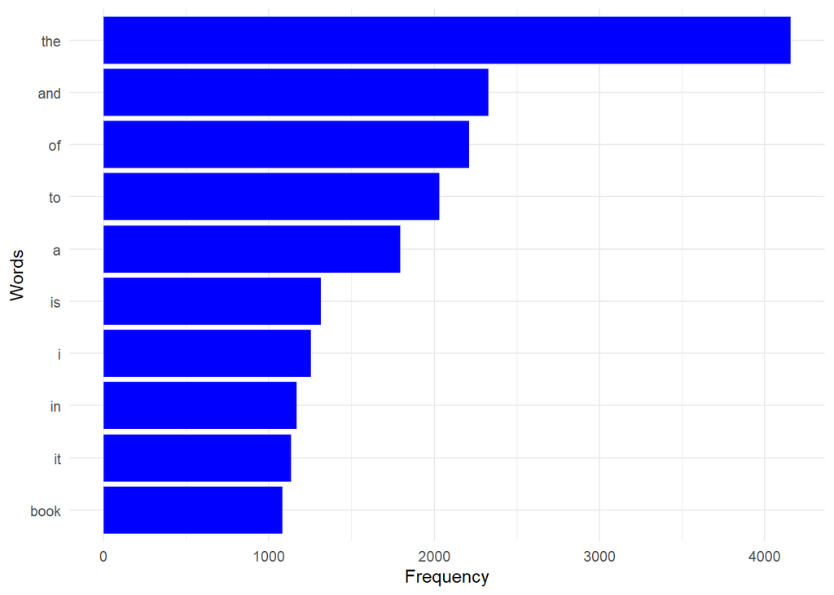

```r
word_counts <- word_tokenized_data %>%
  count(word, sort = TRUE) # Counts the occurences of each word and sorts.

ggplot(word_counts[1:10, ], aes(x = reorder(word, n), y = n)) + # Plots first 10 rows of word counts, with word (ordered by n) on the x axis and n on the y axis
  geom_col(fill = "blue") + # Sets colours of bars to blue
  labs(x = "Words", y = "Frequency") + # Defines x and y labels
  coord_flip() + # Flips coordinates so words go on the y axis (for readability)
  theme_minimal() # Sets theme of visualisation
```

##### Word Cloud

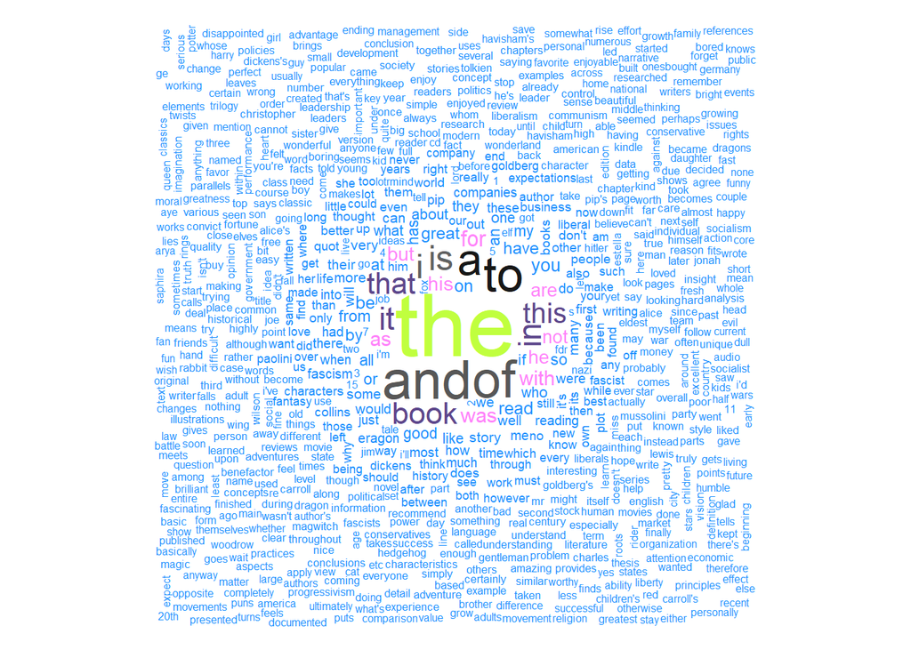

```r
suppressWarnings({
  set.seed(1)
  wordcloud(words = word_counts$word,
            freq = word_counts$n,
            min.freq = 10,
            random.order=FALSE,
            random.color=FALSE,
            colors = sample(colors(), size = 10)
            )
})
```

#### Plot of top 10 bigrams

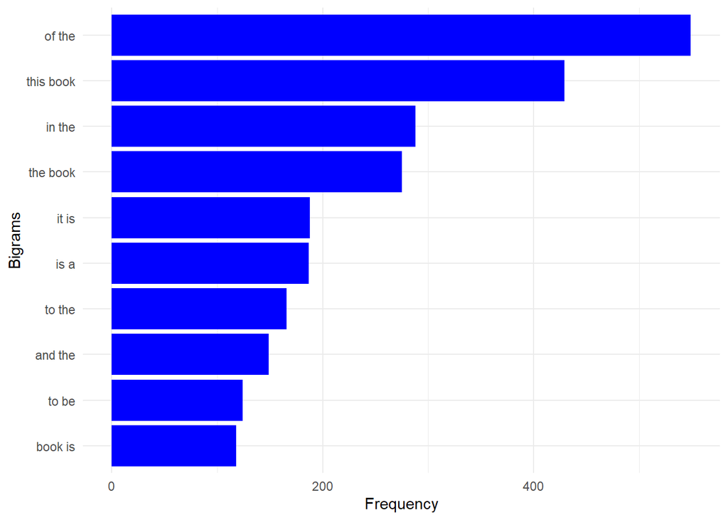

```r
bigram_counts <- bigram_tokenized_data %>%
  count(bigram, sort = TRUE)

ggplot(bigram_counts[1:10, ], aes(x = reorder(bigram, n), y = n)) +
  geom_col(fill = "blue") +
  labs(x = "Bigrams", y = "Frequency") +
  coord_flip() +
  theme_minimal()
```

It can be conclude that from the above word cloud and the horizontal barchart the highest frequent word is “the” and follows by “and”, “of”, “to”, “a” where these does not carry any meaning of the subject of the each book title. further it could be observed from the bi gram as well. Accordingly to get a meaningful idea needed to clean the above text data as follows.

#### Cleaning Data

```r
# Define additional stop words
additional_stop_words <- tibble(word = c("book", "read"))

# Combine with existing stop words
stop_words <- bind_rows(stop_words, additional_stop_words)

clean_tokens <- word_tokenized_data %>%
  anti_join(stop_words, by = "word") # Removes stop words

clean_tokens$word <- gsub("[^a-zA-Z ]", "", clean_tokens$word) %>% # Remove special characters and numbers
  na_if("") %>% # Replaces empty strings with NA
  lemmatize_words() # Lemmatizes text

# Removes null values
clean_tokens <- na.omit(clean_tokens)

# Text can be untokenized and then retokenized to get cleaned bigrams

untokenized_data <- clean_tokens %>%
  group_by(Review_no) %>%
  summarize(clean_review = paste(word, collapse = " ")) %>% # for each review number, takes every word and joins them with spaces
  inner_join(book_data_1[,c("Title", "Review_title", "Review_text", "Publisher", "First_author", "Genre","Review_no")], by="Review_no") # Joins cleaned reviews to original df

clean_bigrams <- untokenized_data %>%
  unnest_tokens(output = bigram, input = "clean_review", token = "ngrams", n=2, to_lower = TRUE) # Tokenize word column to bigrams
```

#### Visualization after Cleaning

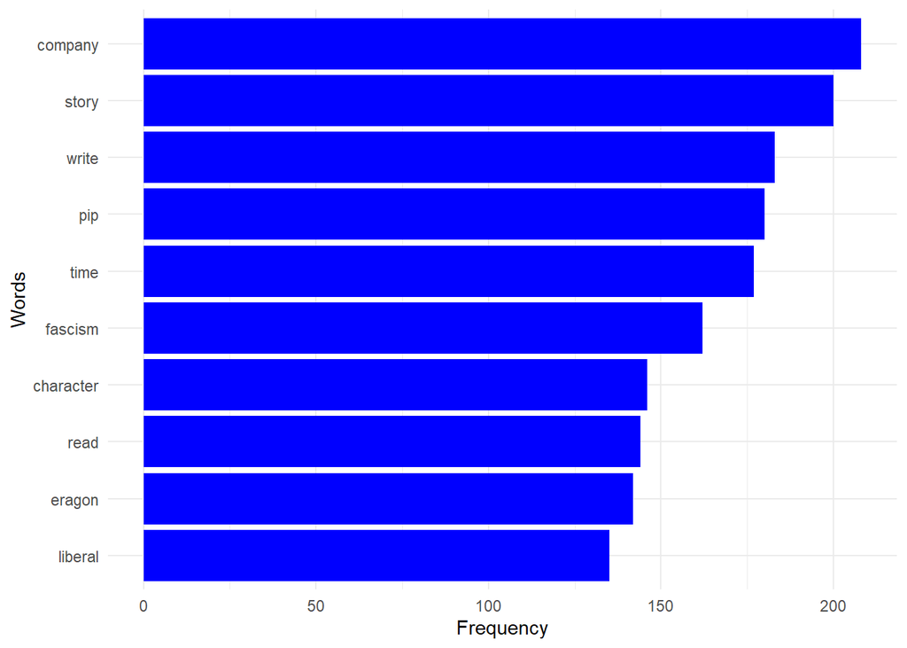

```r
word_counts <- clean_tokens %>%
  count(word, sort = TRUE)

top_words <- top_n(word_counts,10,n)$word

filtered_word_counts <- filter(word_counts, word %in% top_words)
filtered_word_counts$word <- factor(filtered_word_counts$word, levels = top_words[length(top_words):1])

ggplot(filtered_word_counts, aes(x = reorder(word, n), y = n)) +
  geom_col(fill = "blue") +
  labs(x = "Words", y = "Frequency") +
  coord_flip() +
  theme_minimal()
```

The above horizontal frequency plot of top 10 words, shows the highest frequent word is the “company” and second is the “story”. Further the third (write), fourth (pip) and fifth (time) have almost similar frequencies. These nouns could be more informative than previous analysis(without cleaning) about book reviews.

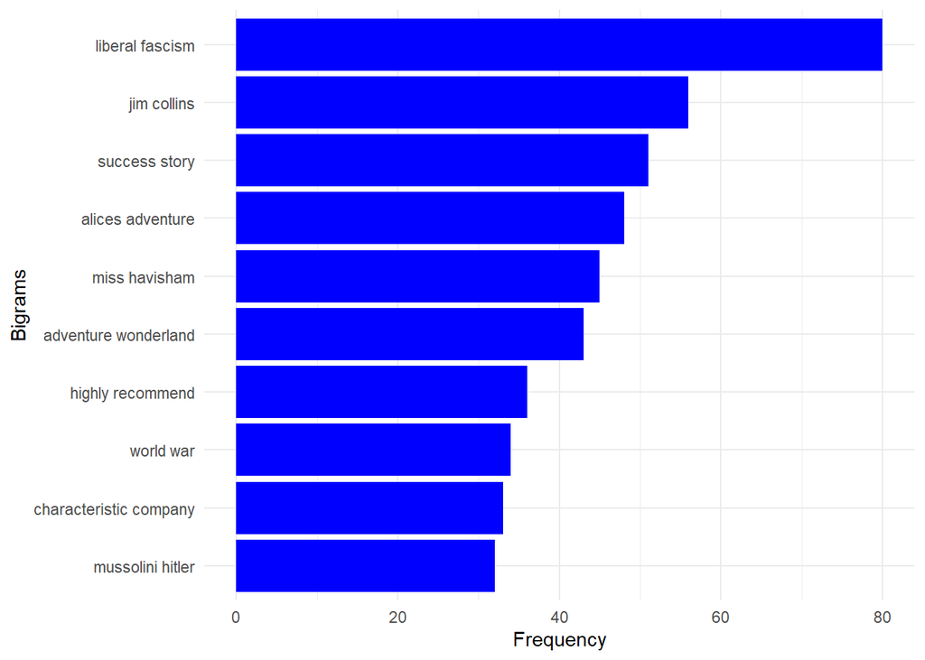

```r
bigram_counts <- clean_bigrams %>%
  count(bigram, sort = TRUE)

top_bigrams <- top_n(bigram_counts,10,n)$bigram

filtered_bigram_counts <- filter(bigram_counts, bigram %in% top_bigrams)
filtered_bigram_counts$bigram <- factor(filtered_bigram_counts$bigram, levels = top_bigrams[length(top_bigrams):1])

ggplot(filtered_bigram_counts, aes(x = reorder(bigram, n), y = n)) +
  geom_col(fill = "blue") +
  labs(x = "Bigrams", y = "Frequency") +
  coord_flip() +
  theme_minimal()
```

Furthermore the bigram plot also shows the highest number of frequent pair of word is “liberal fascism” which is 80 times and the second frequent pair is “jim collins”. The tenth pair is mussolini hitler. Last three pairs of words shows slight changes in frequency.

In conclusion without conducting proper text cleaning, not only the inbuilt stop words also considering the domain knowledge, could not get a proper idea of the words in the review.

#### Top 10 Words & Bigrams grouped by Title

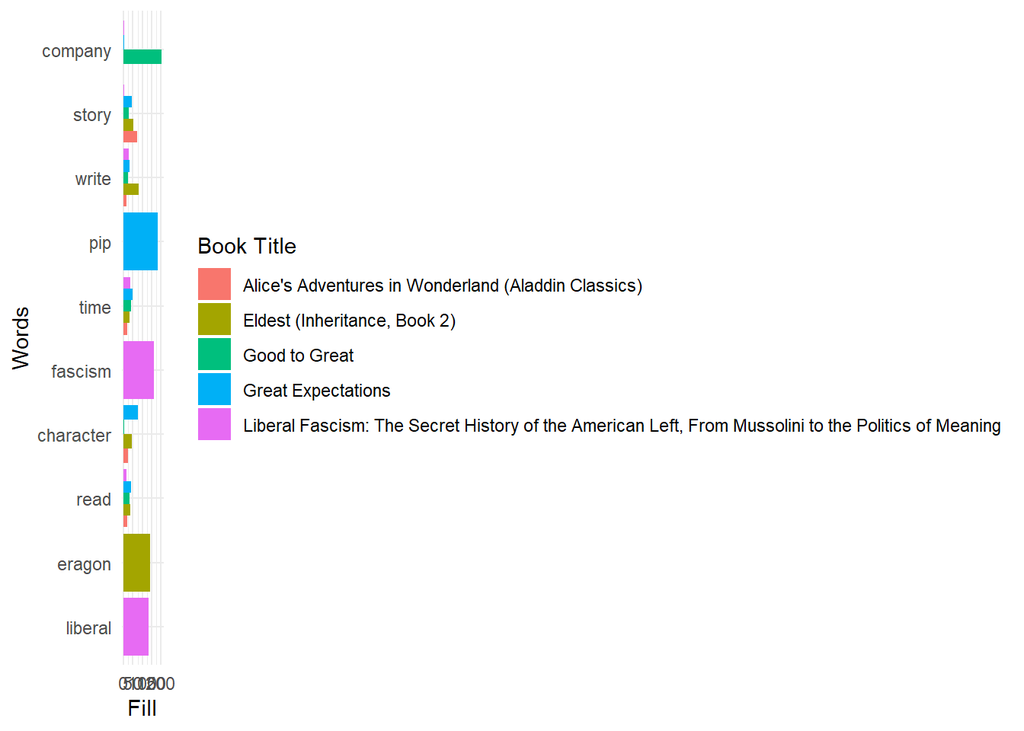

```r
# Grouped Words
top_words <- top_n(word_counts,10,n)$word # Gets a vector of top 10 words

# Groups clean_tokens by Title and counts the number of occurences of each word, and filters to only the top 10 words.
grouped_count <- group_by(clean_tokens, Title) %>%
  count(word) %>%
  filter(word %in% top_words)

grouped_count$word <- factor(grouped_count$word, levels = top_words[length(top_words):1]) # Orders the top words according to overall frequency

#Create the plot
ggplot(data = grouped_count, aes(x = word, y = n, fill = Title)) + # Fill keyword allows groupings
  geom_col(position = "dodge") + # position = dodge creates grouped bar chart
  labs(x = "Words", y = "Fill", fill = "Book Title") +
  coord_flip() +
  theme_minimal()
```

In further tokenized words has been analysed grouping by book titles. Accordingly it can be observed that word “company” is the most frequent word in “Good to Great” book. The word “liberal” and “fascism” is highly found in the book of Liberal Fascism. Accodingly could be identify which book has most frequent words. based on that it can be concluded the set of most frequent words in each book title. The clear image is attached in the repository by the name Grouped_word_plot.png

[figure not shown]

```r
# Grouped Bigrams
top_bigrams <- top_n(bigram_counts,10,n)$bigram

grouped_count <- group_by(clean_bigrams, Title) %>%
  count(bigram) %>%
  filter(bigram %in% top_bigrams)

grouped_count$bigram <- factor(grouped_count$bigram, levels = top_bigrams[length(top_bigrams):1])

ggplot(data = grouped_count, aes(x = bigram, y = n, fill = Title)) +
  geom_col(position = "dodge") +
  labs(x = "Bigrams", y = "Fill", fill = "Book Title") +
  coord_flip() +
  theme_minimal()
```

#### Creating Word Cloud

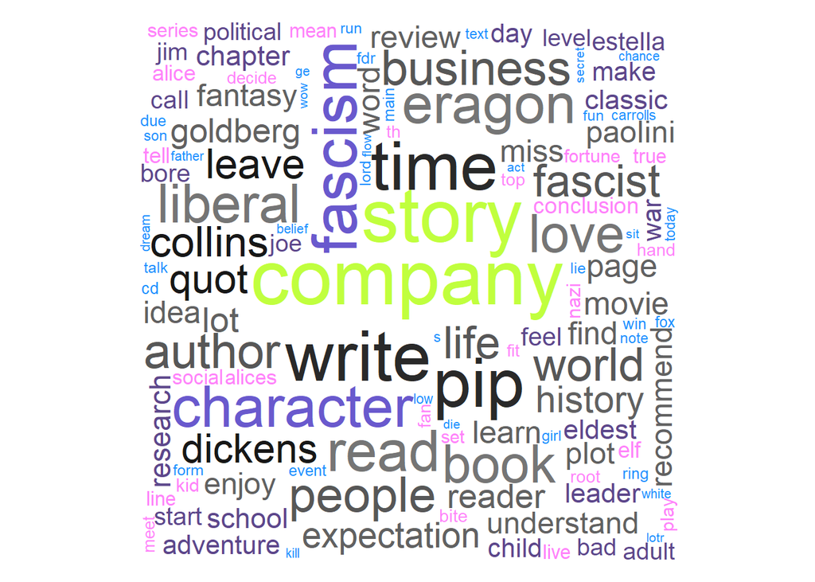

```r
suppressWarnings({
  set.seed(1)
  wordcloud(words = word_counts$word,
            freq = word_counts$n,
            min.freq = 10,
            random.order=FALSE,
            random.color=FALSE,
            colors = sample(colors(), size = 10))
})
```